# `youdrawitR`: Integrating Interactive Graphical Testing into the `ggplot2` Ecosystem

Alisa Krasilnikov, Dr. Emily Robinson, Dillon Murphy

## Graphs are Statistical Tools

- Visualization turns raw data into accessible narratives (Schneider et al. 2024)
- People make decisions by looking at charts (Padilla et al. 2018)
  - Statistical charts are a central way people engage with data

[figure not shown]

U.S. Environmental Protection Agency and U.S. Forest Service (2026)

## Graphical Testing

- Important to ensure information is conveyed correctly
- Certain charts are more accurate than others (Cleveland and McGill 1984)
- Does not necessarily align with statistical intuition (Mosteller et al. 1981)

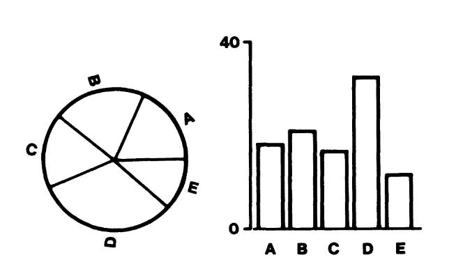

Early graphical testing from Cleveland and McGill (1984) showing similar segments (ex. B and C) are easier to distinguish in barplots

## Modern Graphical Testing

- `Explicit` and `implicit` (VanderPlas et al. 2020)
  - **Explicit:** Answer specific questions about a graph
  - **Implicit:** Have the user infer the question
- Statistical lineups – `nullabor` package (Wickham et al. 2024)

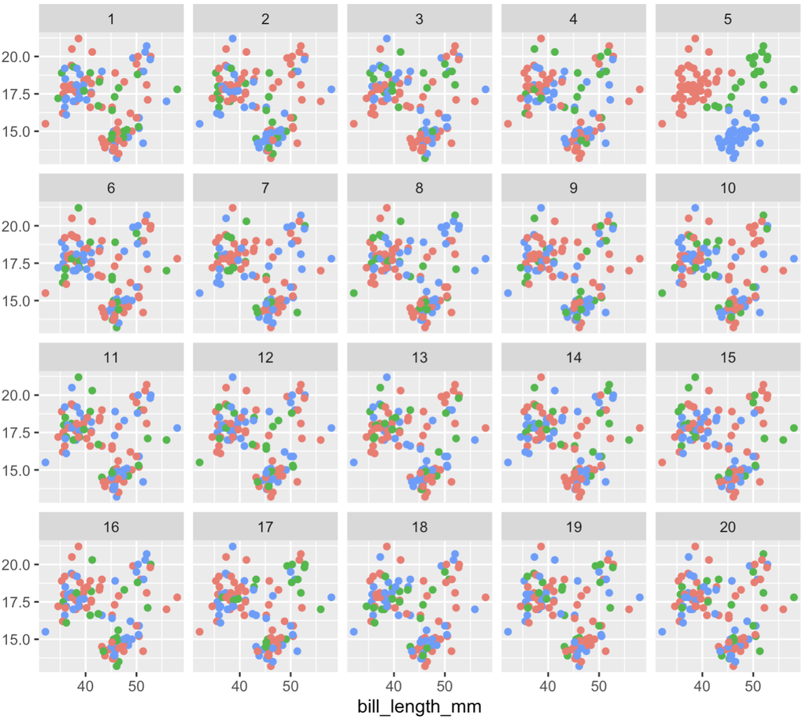

`nullabor` plot displaying true `palmerpenguins` dataset (Horst et al. 2020) amongst randomized groupings

## The ‘You Draw It’ Idea

- **Interactive Graphics** have become more prevalent
- ‘You Draw It’ introduced by the **New York Times**
- Show viewers part of a trend + ask them to **draw the rest** (Katz 2017)

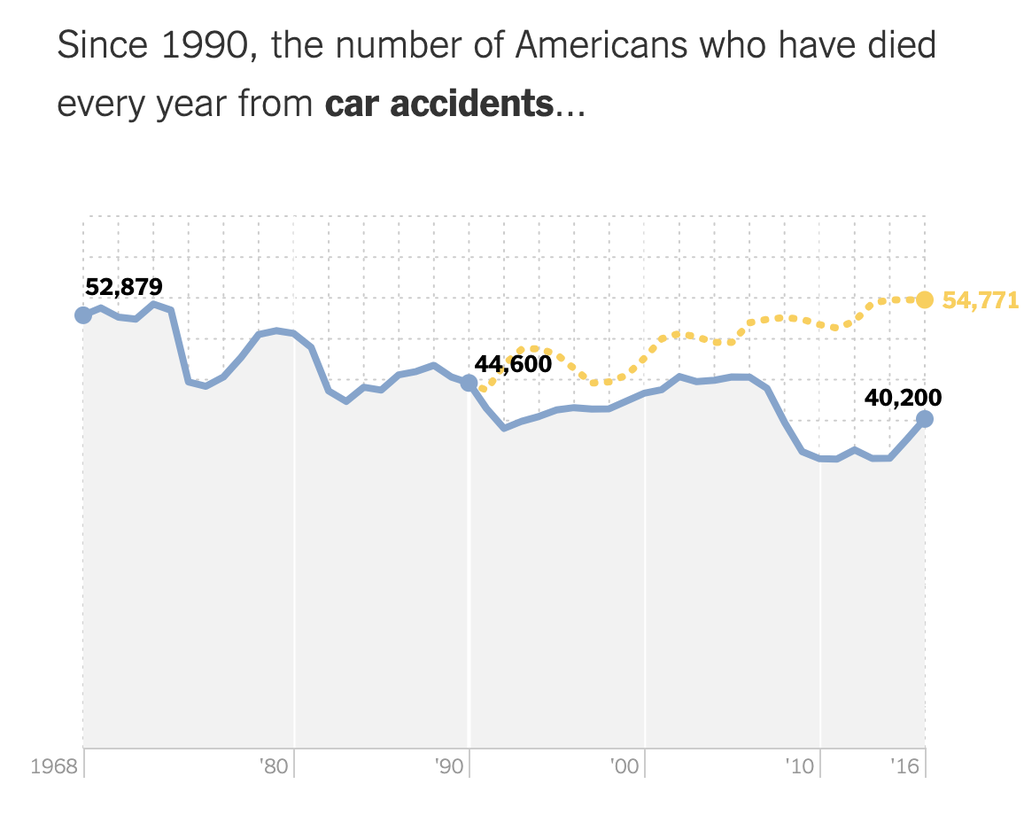

NYT ‘You Draw It’ graph, displaying the true trend after the user has completed drawing (Katz 2017)

## `youdrawitR` for Graphical Testing

- Originally modified by Dr. Emily Robinson
  - Testing perception of log vs. linear scales (2022)
  - Designed to render within Shiny to receive user input
- Built as an R package by Dillon Murphy et al. (2025)

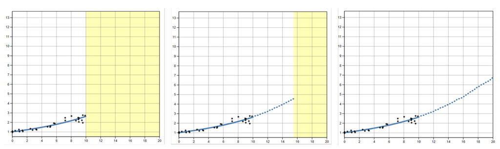

## The Problem with the Old `youdrawitR`

- Not accessible to broader R community of graphics researchers
- Not easily extensible to new plot types + other aesthetic features

## The new `youdrawitR`

[figure not shown]

## **Solution:** A `ggplot2`-Native Interface

```r
library(youdrawitR)

(ggplot(data = mtcars, aes(x = wt, y = mpg)) +
  geom_point() +
  labs(x = "Weight", y = "Miles Per Gallon")) |>
drawit()
```

- Pass a `ggplot2` object directly into `drawit()` or `sketchit()`
- No JavaScript required
- Interactivity as a **layer**, just like a geom or theme

The statistical visualization community works in **`ggplot2`**, so why should interactive testing be any different?

## `r2d3`

(Strayer et al. 2022)

```r
  youdrawit_plot <- r2d3(
    data = payload,
    script = system.file("d3/multiLayer.js", package = "youdrawitR"),
    dependencies = deps,
    options = options,
    width = width,
    height = height
  )
```

- Takes in data from R
- Passes through JavaScript D3 file
- Outputs htmlwidget

## Restructuring of `youdrawitR`

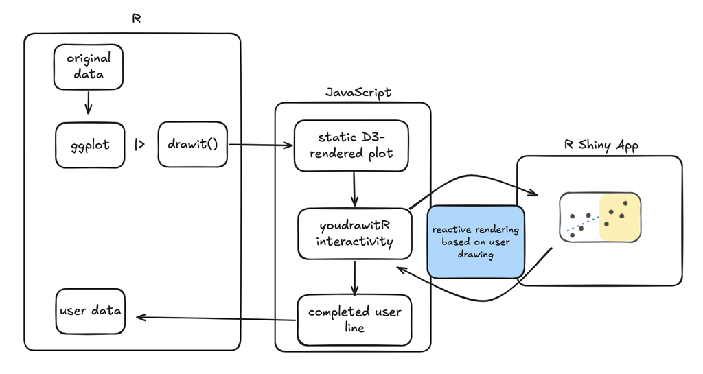

## Restructuring of `youdrawitR`

[figure not shown]

```javascript
// Layer render loop
(data.layers || []).forEach(layer => {

  const rendererName = "render" + capitalize(layer.geom_type) + "Layer";
  const renderer = window[rendererName];

  if (typeof renderer !== "function") return;

  ...

  renderer(svg, plot, layer);
});

...

// Attach drawit if called
if (options?.drawit && window.youdrawitAttachDrawit) {
  window.youdrawitAttachDrawit(
    svg,
    width,
    height,
    data.layers?.[0]?.data,
    options
  );
}
...
```

## Restructuring of `youdrawitR`

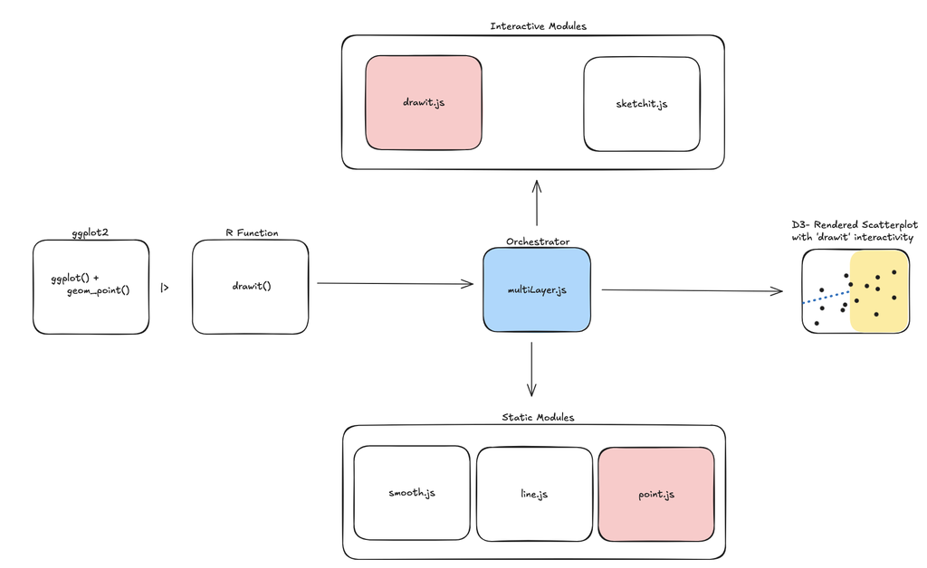

`youdrawitR` separation of modules

## `drawit()`: Structured Prediction

- User draws a predicted trend across a **highlighted region**
- Designed for **one-to-one** x-y matching
- Useful for: regressions, forecasting tasks, reveals of true trend

[interactive chart not shown]

## `drawit()`: Key Parameters

| Argument | Purpose |
| --- | --- |
| `draw_start` | Where drawing begins on the x-axis |
| `show_on_finish` | Reveals secondary geometry |
| `smoother` | Controls point binning in draw space |
| `interpolator` | Controls density of intermediate points |

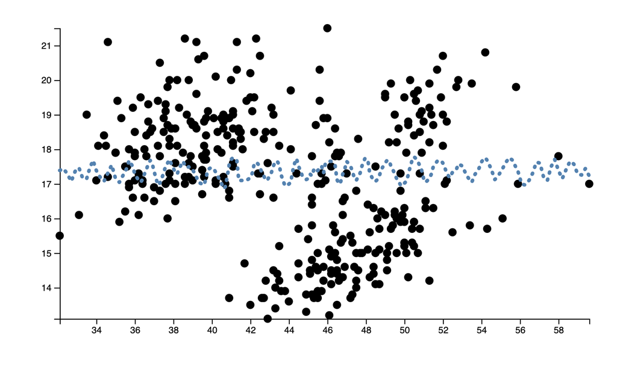

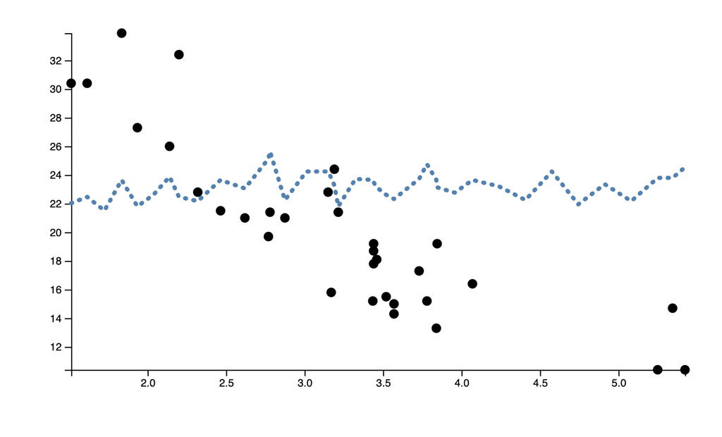

## `sketchit()`: Freeform Drawing

- No one-to-one data matching required
- Users can draw **multiple lines**
- Useful for: clusters, point detection

[interactive chart not shown]

## `sketchit()`: Key Parameters

| Argument | Purpose |
| --- | --- |
| `palette` | Set of colors available for drawing |
| `starting_color` | Initial drawing color |
| `button_position` | Position of control interface |
| `min_lines` / `max_lines` | Controls the number of lines the user can draw |

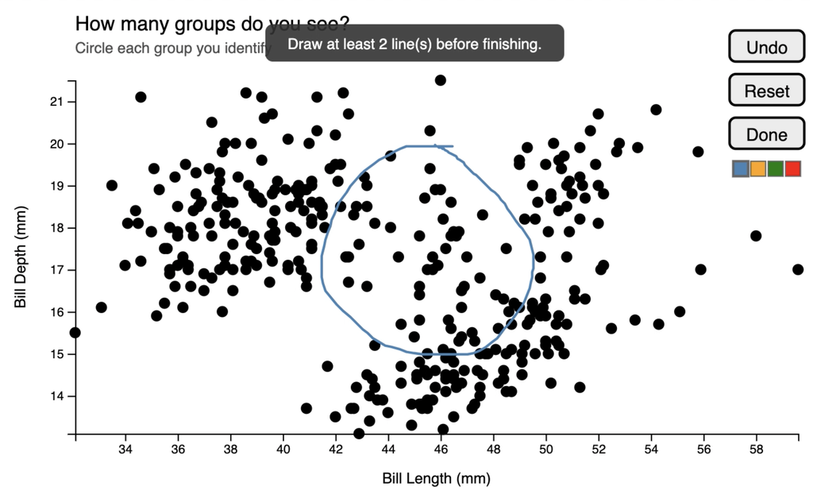

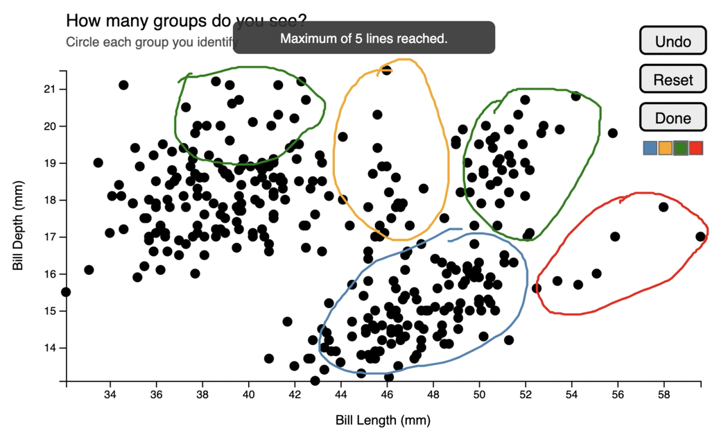

## Shiny Integration

Both functions work inside Shiny apps and return user-drawn data as a reactive tibble:

```r
res <- drawit(p, shiny_message_loc = "my_input")

# res$youdrawit_plot -> the widget
# res$points() -> reactive tibble of drawn (x, y) values
```

Captured data aligns with original x-values, ready for **merging and analysis**.

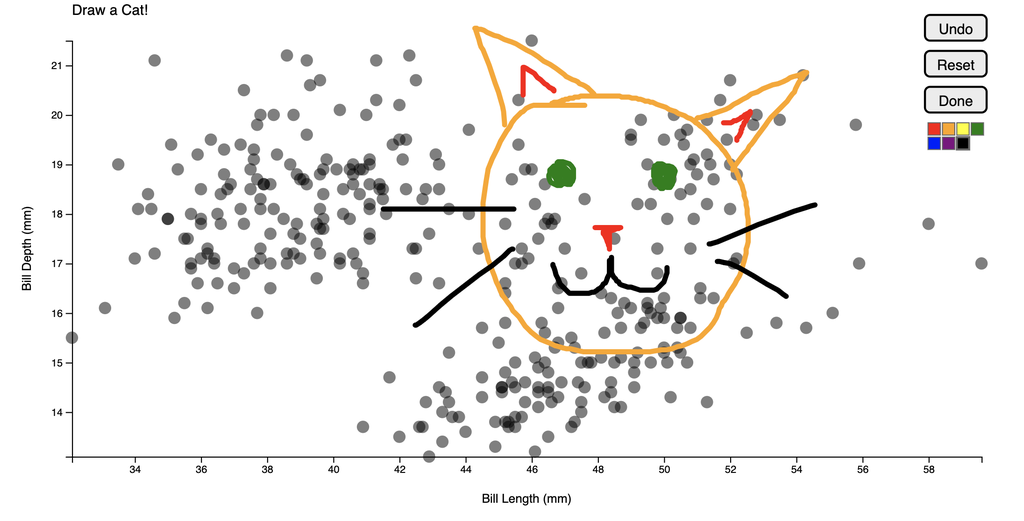

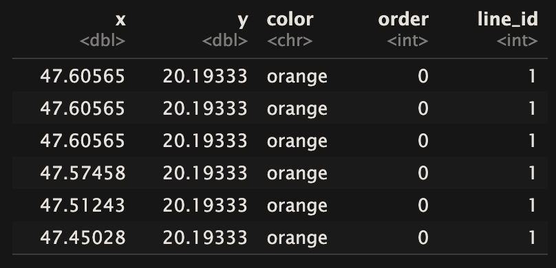

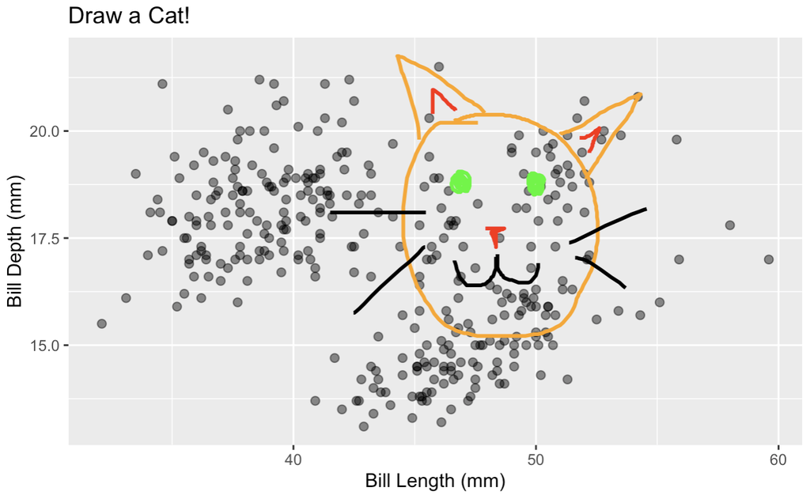

## The Bigger Picture: An Interactive Grammar

`youdrawitR` treats interactivity as a **grammatical layer** that can ba tacked onto a plot.

This lowers the barrier and keeps researchers within familiar `ggplot2` syntax.

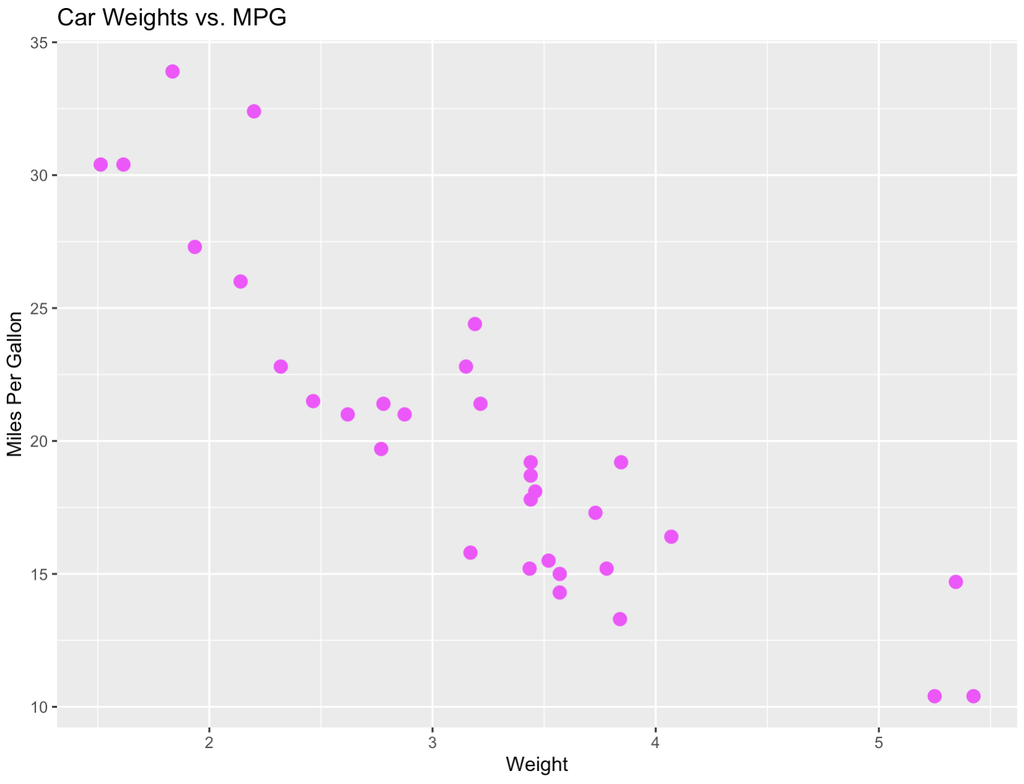

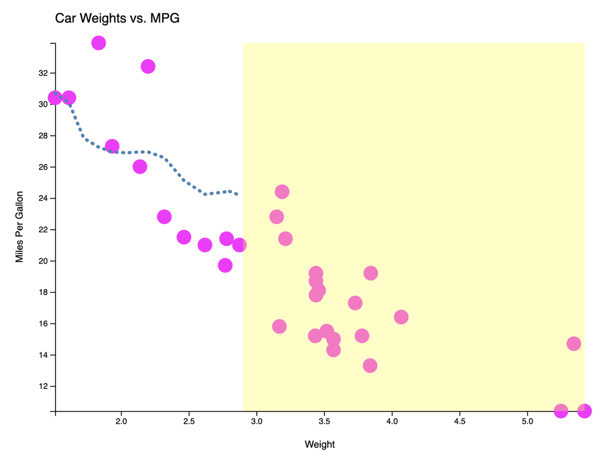

## Usability Testing

- Recruited 9 participants
  - Familiar with `ggplot2`
  - Backgrounds primarily in graphical testing and education
- Thinkaloud (25 mins) + Semi-structured interview (5 mins) (Rogers et al. 2023)
- User vs. **Implementer**

**Interview Questions:**

1. How would you describe your overall experience?
2. Were there any parts of the task you struggled with?
3. Do you see yourself using this tool?
4. What kinds of tasks would you use this for?
5. How does this compare to other available tools?
6. What features would make you more likely to adopt it?

## Usability Testing

- **People found it easy to use and intuitive**
- **Had reasons to use it:**
  - Research
  - Annotation
  - Education
- **Wanted some features:**
  - Exporting with drawing
  - Data tracking in non-Shiny environment
  - Buttons in `drawit()`

## What’s Next

- Extend geometry: bar charts, histograms, boxplots, etc.
  - Particularly interested in maps
- **Python support** via `plotnine` integration
- CRAN release

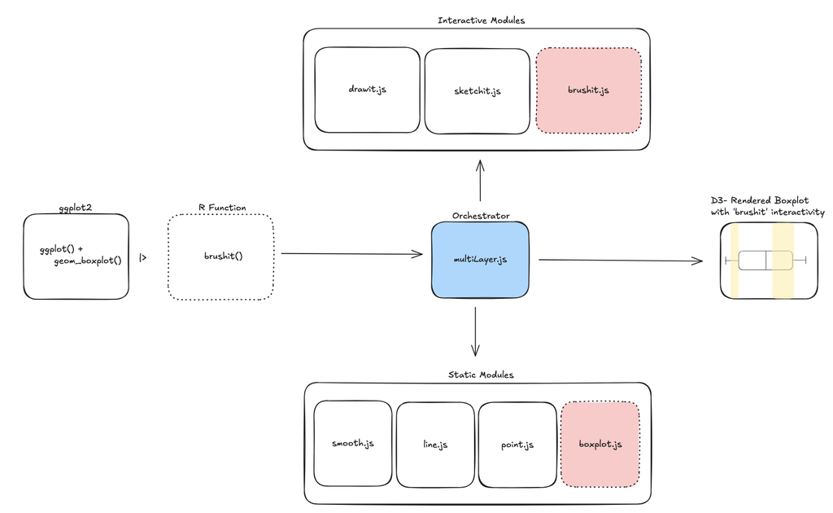

Theoretical future addition of a boxplot with `brushit` interaction

## Thank You!

[figure not shown]

Email: `alisa.krass@gmail.com` Documentation: `https://alisa-krasilnikov.github.io/youdrawitR/`

*Questions?*

## References

Aisch, Gregor, Amanda Cox, and Kevin Quealy. 2015. *You Draw It: How Family Income Affects Children’s College Chances*. *The New York Times*. https://www.nytimes.com/interactive/2015/05/28/upshot/you-draw-it-how-family-income-affects-childrens-college-chances.html.

Bartonicek, Adam. 2025. *Plotscaper: Explore Your Data with Interactive Figures*. https://bartonicek.github.io/plotscaper/.

Bostock, Michael, Vadim Ogievetsky, and Jeffrey Heer. 2011. “D3: Data-Driven Documents.” *IEEE Transactions on Visualization and Computer Graphics* 17 (12): 2301–9. https://doi.org/10.1109/TVCG.2011.185.

Buja, Andreas, Dianne Cook, Heike Hofmann, et al. 2009. “Statistical Inference for Exploratory Data Analysis and Model Diagnostics.” *Royal Society Philosophical Transactions A* 367 (1906): 4361–83. https://doi.org/10.1098/rsta.2009.0120.

Chang, Winston, Joe Cheng, JJ Allaire, et al. 2026. *Shiny: Web Application Framework for r*. https://doi.org/10.32614/CRAN.package.shiny.

Cleveland, William S., and Robert McGill. 1984. “Graphical Perception: Theory, Experimentation, and Application to the Development of Graphical Methods.” *Journal of the American Statistical Association* 79 (387): 531–54. https://doi.org/10.2307/2288400.

Cleveland, William S., and Robert McGill. 1985. “Graphical Perception and Graphical Methods for Analyzing Scientific Data.” *Science* 229 (4716): 828–33. https://doi.org/10.1126/science.229.4716.828.

Cleveland, William S., and Robert McGill. 1987. “Graphical Perception: The Visual Decoding of Quantitative Information on Graphical Displays of Data.” *Journal of the Royal Statistical Society: Series A (General)* 150 (3): 192–229. https://doi.org/10.2307/2981473.

Henderson, Harold V, and Paul F Velleman. 1981. “Building Multiple Regression Models Interactively.” *Biometrics* 32 (2): 391–411. https://doi.org/10.2307/2530428.

Horst, Allison Marie, Alison Presmanes Hill, and Kristen B Gorman. 2020. *Palmerpenguins: Palmer Archipelago (Antarctica) Penguin Data*. https://doi.org/10.5281/zenodo.3960218.

Katz, Josh. 2017. “You Draw It: Just How Bad Is the Drug Overdose Epidemic?” https://www.nytimes.com/interactive/2017/04/14/upshot/drug-overdose-epidemic-you-draw-it.html.

Krasilnikov, Alisa, Dillon Murphy, Emily Robinson, Heike Hofmann, and Susan VanderPlas. 2026. *youdrawitR: ’You Draw It’*. https://github.com/Alisa-Krasilnikov/youdrawitR.

Le, Dylan, Rachel Rogers, and Emily Robinson. 2026. “Clusters, Trends, and Choices: Feature Selection in Interactive Statistical Graphics.” *Journal of Data Science*, ahead of print. https://doi.org/10.6339/26-JDS1221.

Mosteller, Frederick, Andrew F Siegel, Edward Trapido, and Cleo Youtz. 1981. “Eye Fitting Straight Lines.” *The American Statistician* 35 (3): 150–52. https://doi.org/10.2307/2683983.

Murphy, Dillon, Susan VanderPlas, Heike Hofmann, and Emily Robinson. 2025. *youdrawitR0: ’You Draw It’*. https://earobinson95.github.io/youdrawitR0/.

Padilla, Lace M., Sarah H. Creem-Regehr, Mary Hegarty, and Jeanine K. Stefanucci. 2018. “Decision Making with Visualizations: A Cognitive Framework Across Disciplines.” *Cognitive Research: Principles and Implications* 3 (29). https://doi.org/10.1186/s41235-018-0120-9.

Prevos, Peter. 2023. *Visualising Data with ggplot2: Water Quality Data*. [Https://lucidmanager.org/data-science/visualising-data-with-ggplot2/](https://lucidmanager.org/data-science/visualising-data-with-ggplot2/).

R Core Team. 2025. *R: A Language and Environment for Statistical Computing*. R Foundation for Statistical Computing. https://www.R-project.org/.

Robinson, Emily Anna. 2022. “Human Perception of Exponentially Increasing Data Displayed on a Log Scale Evaluated Through Experimental Graphics Tasks.” PhD thesis, University of Nebraska-Lincoln. https://digitalcommons.unl.edu/dissertations/AAI29257475/.

Robinson, Emily, Reka Howard, and Susan VanderPlas. 2022. “Eye Fitting Straight Lines in the Modern Era.” *Journal of Computational and Graphical Statistics* 32 (4): 1537–44. https://doi.org/10.1080/10618600.2022.2140668.

Rogers, Yvonne, Helen Sharp, and Jennifer Preece. 2023. “Data Gathering.” Chap. 8 in *Interaction Design: Beyond Human-Computer Interaction*, 5th ed. John Wiley & Sons.

Rutter, Harry, Simon Parker, Will Stahl-Timmins, et al. 2021. “Visualising SARS-CoV-2 Transmission Routes and Mitigations.” *BMJ* 375. https://doi.org/10.1136/bmj-2021-065312.

Sabat, Magdalena, Nandita Dhanda, Rohit Sahasrabuddhe, and Anne Urai. 2026. *DrawIt for Qualtrics*. Amsterdam Complexity School on Climate Change. https://github.com/cocosys-lab/2026_acscc_changeperception.

Schneider, Claudia R., John R. Kerr, Sarah Dryhurst, and John A. D. Aston. 2024. “Communication of Statistics and Evidence in Times of Crisis.” *Annual Review of Statistics and Its Application* 11: 1–26. https://doi.org/10.1146/annurev-statistics-040722-052011.

Sievert, Carson. 2020. *Interactive Web-Based Data Visualization with r, Plotly, and Shiny*. Chapman; Hall/CRC. https://plotly-r.com.

Strayer, Nick, Javier Luraschi, and JJ Allaire. 2022. *R2d3: Interface to ’D3’ Visualizations*. https://doi.org/10.32614/CRAN.package.r2d3.

Swayne, Deborah F, Duncan Temple Lang, Andreas Buja, and Dianne Cook. 2003. “GGobi: Evolving from XGobi into an Extensible Framework for Interactive Data Visualization.” *Computational Statistics & Data Analysis* 43 (4): 423–44. https://doi.org/10.1016/S0167-9473(02)00286-4.

team, The plotnine development. n.d. *Plotnine: A Grammar of Graphics for Python*. https://doi.org/https://doi.org/10.5281/zenodo.1325308.

U.S. Environmental Protection Agency, and U.S. Forest Service. 2026. *AirNow Fire and Smoke Map*. [Https://fire.airnow.gov/](https://fire.airnow.gov/).

VanderPlas, Susan, Dianne Cook, and Heike Hofmann. 2020. “Testing Statistical Charts: What Makes a Good Graph?” *Annual Review of Statistics and Its Application* 7: 61–88. https://doi.org/10.1146/annurev-statistics-031219-041252.

VanderPlas, Susan, and Heike Hofmann. 2017. “Clusters Beat Trend!? Testing Feature Hierarchy in Statistical Graphics.” *Journal of Computational and Graphical Statistics* 26 (2): 231–42. https://doi.org/10.1080/10618600.2016.1209116.

Wickham, Hadley. 2010. “A Layered Grammar of Graphics.” *Journal of Computational and Graphical Statistics* 19 (1): 3–28. https://doi.org/10.1198/jcgs.2009.07098.

Wickham, Hadley. 2016. *Ggplot2: Elegant Graphics for Data Analysis*. Springer-Verlag New York. https://ggplot2.tidyverse.org.

Wickham, Hadley, Niladri Roy Chowdhury, Di Cook, Heike Hofmann, and Måns Thulin. 2024. *Nullabor: Lineup and Rorschach Plots for Visual Inference*. https://CRAN.R-project.org/package=nullabor.

Wilkinson, Leland. 2005. *The Grammar of Graphics*. 2nd ed. Statistics and Computing. Springer.